# Creating alpha-hulls in `galah`

Margot Schneider, Fonti Kar

2022-09-13

### Creating $\alpha$-hulls in `galah`

- What is convex polygon/hull?
- What are they for in spatial analyses?
- What is the distinction between convex polygons and alpha hulls

#### A toy example with `iris`

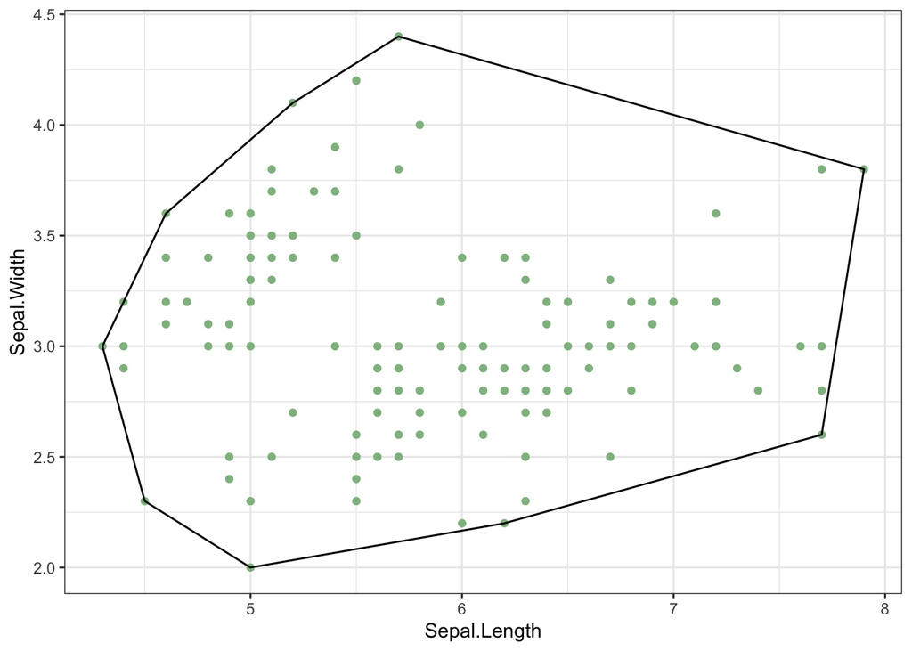

```r
data(iris)
iris_sepals <- iris[,1:2]

# remove duplicate datapoints
iris_sepals <- iris_sepals[!duplicated(paste(iris_sepals$Sepal.Length, iris_sepals$Sepal.Width)), ]

# a convex hull
convexhull <- chull(iris_sepals)

# create the outline of the hull
hull_pts <- c(convexhull, convexhull[1])

# plot the points and convex hull
ggplot() +
  geom_point(data = iris_sepals, aes(Sepal.Length, Sepal.Width), colour = "darkseagreen") +
  geom_polygon(data = iris_sepals[hull_pts, ], aes(Sepal.Length, Sepal.Width), fill = NA, colour = "black") +
  theme_bw()
```

This convex hull (drawn in black) is an example of an alpha-shape: all convex hulls are alpha-shapes, but not all alpha-shapes are convex hulls. An alpha-shape doesn’t have to be convex – the lines making up the border of the shape can create concave edges relative to the points in the dataset.

```r
extract_polygons <- function(alpha_obj)
{
  if(class(alpha_obj) != "ashape") stop("extract_polygons requires an ashape")
  edge.df <- as.data.frame(alpha_obj$edges)
  groups <- ns <- xs <- ys <- numeric(nrow(edge.df))
  m <- cbind(edge.df[[1]], edge.df[[2]])
  group <- 1
  repeat {
    i <- which(groups == 0)[1]
    if (length(i) == 0 | is.na(i)) break()
    j <- n <- 1
    repeat {
      groups[i] <- group
      ns[i] <- n
      if(j == 1) xs[i] <- edge.df$x1[i] else xs[i] <- edge.df$x2[i]
      if(j == 1) ys[i] <- edge.df$y1[i] else ys[i] <- edge.df$y2[i]
      next_ind <- which((m[, j] == m[i, j] | m[, (j %% 2 + 1)] == m[i, j]) & groups == 0)
      if (length(next_ind) == 0) break()
      j <- which(m[next_ind,] == m[i, j]) %% 2 + 1
      i <- next_ind
      n <- n + 1
    }
    group <- group + 1
  }
  data.frame(x = xs, y = ys, group = as.factor(groups))[order(groups, ns), ]
}
```

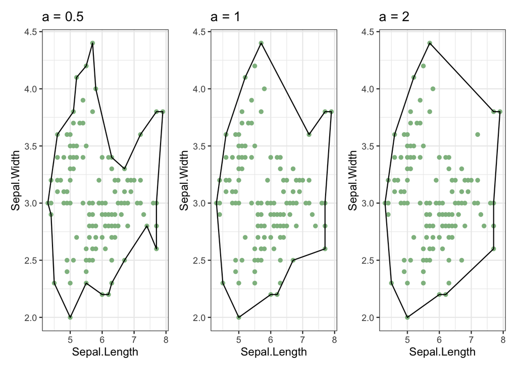

[output not shown]

```r
# We can map this but for now:
# Create alpha hulls
alphashape_0.5 <- ashape(iris_sepals, alpha = 0.5)
alphashape_1 <- ashape(iris_sepals, alpha = 1)
alphashape_2 <- ashape(iris_sepals, alpha = 2)

# Extract polgyons
a_0.5<- extract_polygons(alphashape_0.5)
a_1<- extract_polygons(alphashape_1)
a_2<- extract_polygons(alphashape_2)

a05 <- ggplot() +
  geom_point(data = iris_sepals, aes(Sepal.Length, Sepal.Width), colour = "darkseagreen") +
  geom_polygon(data = a_0.5, aes(x, y), fill = NA, colour = "black") +
  labs(title = "a = 0.5") +
  theme_bw()

a1 <- ggplot() +
  geom_point(data = iris_sepals, aes(Sepal.Length, Sepal.Width), colour = "darkseagreen") +
  geom_polygon(data = a_1, aes(x, y), fill = NA, colour = "black") +
  labs(title = "a = 1") +
  theme_bw()

a2 <- ggplot() +
  geom_point(data = iris_sepals, aes(Sepal.Length, Sepal.Width), colour = "darkseagreen") +
  geom_polygon(data = a_2, aes(x, y), fill = NA, colour = "black") +
  labs(title = "a = 2") +
  theme_bw()

patchwork::plot_layout(a05 + a1 + a2)
```

### Okay lets try do this `galah`

Getting data for a species of Damsel fly

```r
galah_call() |>
  galah_identify("Austroargiolestes calcaris") |>
  galah_select(group = "basic") |>
   atlas_occurrences() -> dfly
```

### Data cleaning steps

```r
# deduplication
dfly |>
  filter(! duplicated(decimalLongitude) | duplicated(decimalLatitude)) -> dfly_ddup

# exclude NA in coordinates
dfly_ddup |>
  filter(! is.na(decimalLongitude) | ! is.na(decimalLatitude) ) -> dfly_clean

dfly_clean |> as.data.frame()
```

## Compute alpha hulls of occurrences

```r
dfly_clean |>
  select(starts_with("deci")) |>
  ahull(alpha = 3) |> plot()
```

## Tranform to `sf` object

```r
dfly_clean |>
  mutate(decimalLatitude = as.numeric(decimalLatitude),
         decimalLongitude = as.numeric(decimalLongitude)) |>
  st_as_sf(coords = c("decimalLongitude", "decimalLatitude"), crs = 4326) -> dfly_sf


aus <- st_transform(ozmaps::ozmap_country, 4326)
```

## For now we are using IA’s cleaned data

```r
ala_df |>
  filter(scientificName == "Austroargiolestes calcaris")  -> test_ala

# Deduplication for computing alpha hulls
test_ala |>
  filter(! duplicated(longitude) | duplicated(latitude))  |>
  select(longitude, latitude) -> data

# Turn occurrence data into sf
test_ala |>
  mutate(latitude = as.numeric(latitude),
         longitude = as.numeric(longitude)) |>
  st_as_sf(coords = c("longitude", "latitude"), crs = 4326) -> occ_sf

# Getting Australia
aus <- st_transform(ozmaps::ozmap_country, 4326)
```

## Computing an alpha hull of occurrences

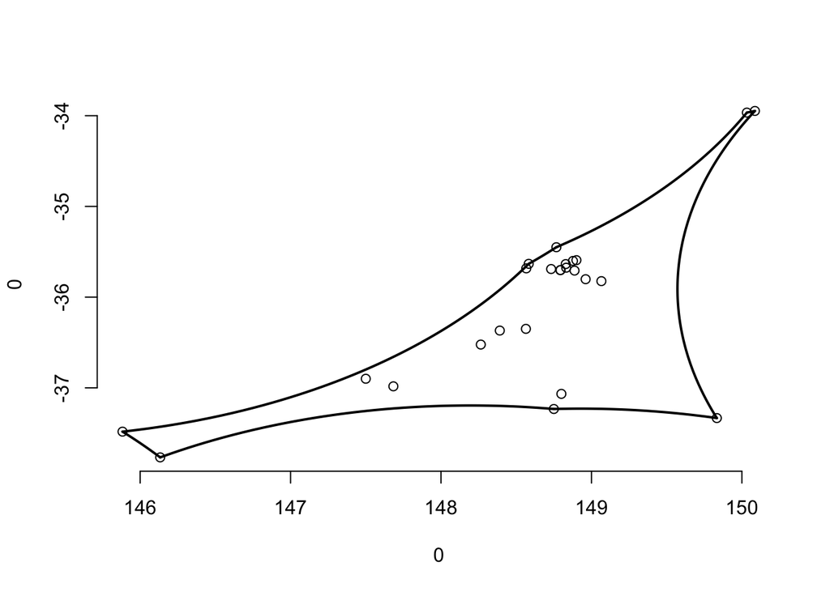

```r
ahull(data, alpha = 4) |> plot()
```

```r
ahull(data, alpha = 4) -> alphahull_1
```

## Turn into `sp` object

```r
hull2spatial::ahull2poly(alphahull_1) -> sp_df

# Transforming into `sf`
hull2spatial::ahull2poly(alphahull_1) |>
  st_as_sf() -> sf_ahull

# Set the datum system
sf_ahull %>% st_set_crs(st_crs(aus)) -> sf_ahull
```

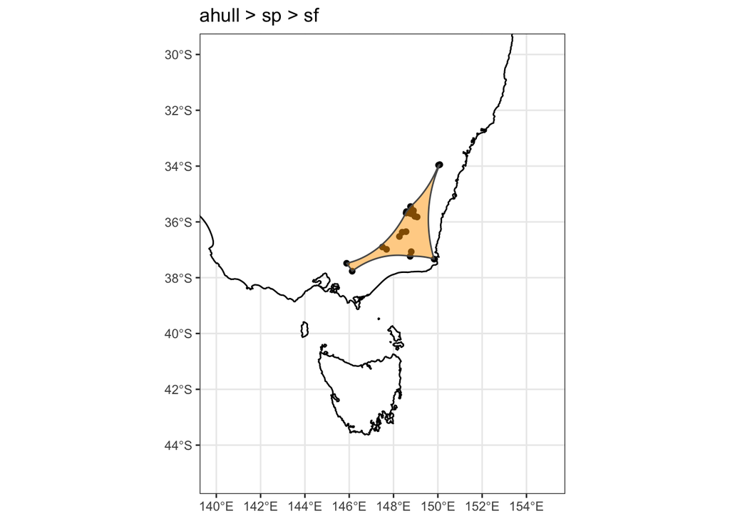

```r
hacked_ahull <- ggplot() +
  geom_sf(data = aus, colour = "black", fill = "white")  +
  geom_sf(data = occ_sf, colour = "black") +
  geom_sf(data = sf_ahull, fill = "orange", alpha = 0.5) +
  coord_sf(xlim=c(140, 155),ylim=c(-30,-45)) +
  guides(colour = guide_legend(override.aes = list(alpha=1))) +
  labs(title = "ahull > sp > sf") +
  theme_bw()

hacked_ahull
```

## concaveman algorithim

I don’t think this is an alpha hull though

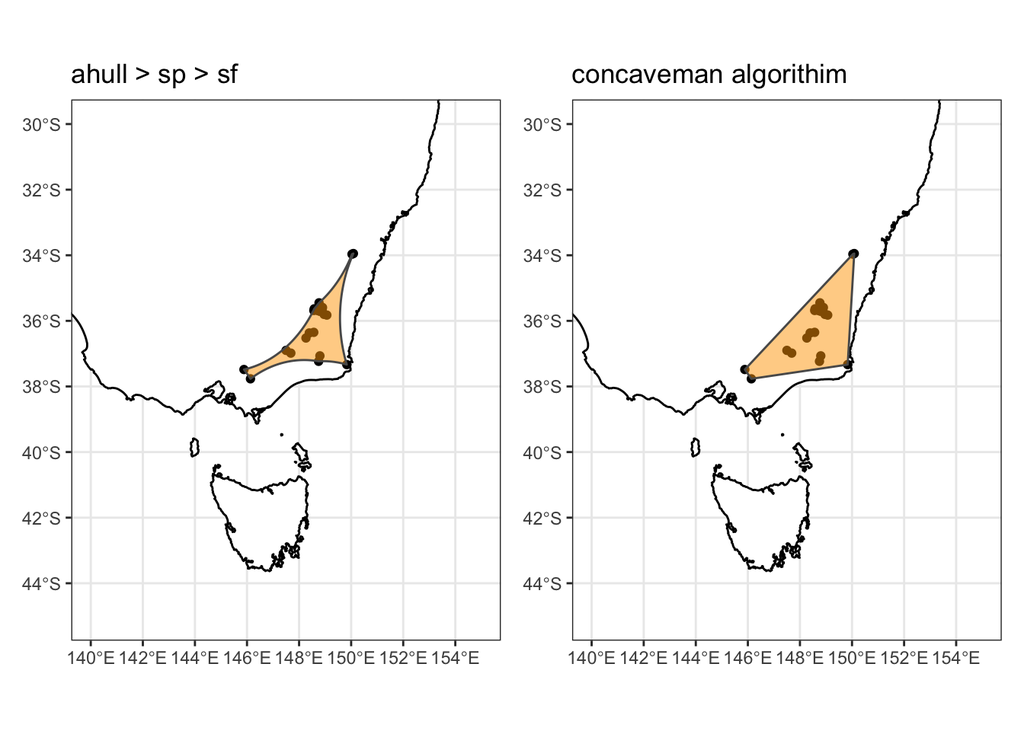

[output not shown]

```r
dat.sf <- st_as_sf(data, coords=c("longitude","latitude"), crs = st_crs(4326))
polygon <- concaveman(dat.sf, concavity = 4)


ccman <- ggplot() +
  geom_sf(data = aus, colour = "black", fill = "white")  +
  geom_sf(data = occ_sf, colour = "black") +
  geom_sf(data = polygon, fill = "orange", alpha = 0.5) +
  coord_sf(xlim=c(140, 155),ylim=c(-30,-45)) +
  labs(title = "concaveman algorithim") +
  theme_bw()

plot_layout(hacked_ahull + ccman)
```

### Resources:

- Existing implementations for getting convex polygons and alpha hulls
  - [`rCAT`](https://cran.r-project.org/web/packages/rCAT/index.html) minimum convex polygons only; no polygons for mapping; endorsed by IUCN and has an accompanying GIS tool
  - [`red`](https://cran.r-project.org/web/packages/red/index.html) minimum convex polygons only; provides a single convex polygon for mapping
  - [`alphahull`](https://cran.r-project.org/web/packages/alphahull/index.html) EOO only, provides polygons for mapping
  - [`ConR`](https://cran.r-project.org/web/packages/ConR/index.html) for both minimum convex polygons or alpha hulls; provides both options for mapping (depends on `alphahull`)
  - [`concaveman`](https://joelgombin.github.io/concaveman/) R wrapper for a very fast 2D concave hull algorithm in Javascript